# Lab 5 - Insurance Costs

Author

Ulises Caro

```python
import sklearn
import pandas as pd
from pandas import get_dummies
import numpy as np
from sklearn.linear_model import *
from sklearn.preprocessing import *
from sklearn.metrics import *
from sklearn.model_selection import *
from plotnine import *
```

**NOTE: All models in this lab use the test_size = 0.2 and random_state = 321. For Cohort B, we learned this in Data mining and Dr. Ross seemed okay with it when discussing it with him given we just learned pipeline in Week 7.**

**An extension for this lab was submitted on Saturday, November 1**

```python
url = "https://www.dropbox.com/s/bocjjyo1ehr5auz/insurance_costs_1.csv?dl=1"
myData = pd.read_csv(url)
myData.head()
```

|  | age | sex | bmi | smoker | region | charges |
| --- | --- | --- | --- | --- | --- | --- |
| 0 | 19 | female | 27.900 | yes | southwest | 16884.92400 |
| 1 | 33 | male | 22.705 | no | northwest | 21984.47061 |
| 2 | 32 | male | 28.880 | no | northwest | 3866.85520 |
| 3 | 31 | female | 25.740 | no | southeast | 3756.62160 |
| 4 | 60 | female | 25.840 | no | northwest | 28923.13692 |

**PART 1**

```python
myData.dtypes
```

|  | 0 |
| --- | --- |
| age | int64 |
| sex | object |
| bmi | float64 |
| smoker | object |
| region | object |
| charges | float64 |

**dtype:** object

**Data summaries**

```python
myData.describe()
```

|  | age | bmi | charges |
| --- | --- | --- | --- |
| count | 431.000000 | 431.000000 | 431.000000 |
| mean | 37.960557 | 30.768898 | 12297.098118 |
| std | 16.363909 | 6.111362 | 11876.527128 |
| min | 18.000000 | 15.960000 | 1131.506600 |
| 25% | 22.000000 | 26.357500 | 2710.444575 |
| 50% | 34.000000 | 30.590000 | 9866.304850 |
| 75% | 55.000000 | 35.272500 | 14510.872600 |
| max | 64.000000 | 49.060000 | 55135.402090 |

```python
myData.nunique()
```

|  | 0 |
| --- | --- |
| age | 47 |
| sex | 2 |
| bmi | 305 |
| smoker | 2 |
| region | 4 |
| charges | 430 |

**dtype:** int64

```python
myData.isna().any() #there are no empty observations in the dataset
```

|  | 0 |
| --- | --- |
| age | False |
| sex | False |
| bmi | False |
| smoker | False |
| region | False |
| charges | False |

**dtype:** bool

**Plots**

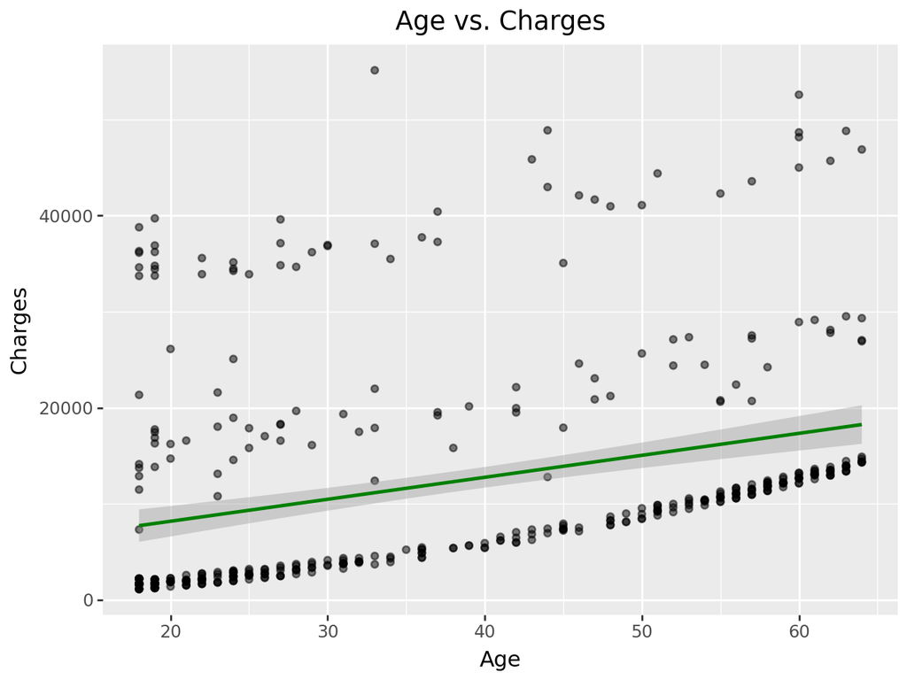

```python
plot1 = (ggplot(myData, aes(x="age", y="charges")) +
         geom_point(alpha=0.5) +
         geom_smooth(method="lm", color="green") +
         labs(title="Age vs. Charges", x="Age", y="Charges"))
plot1
```

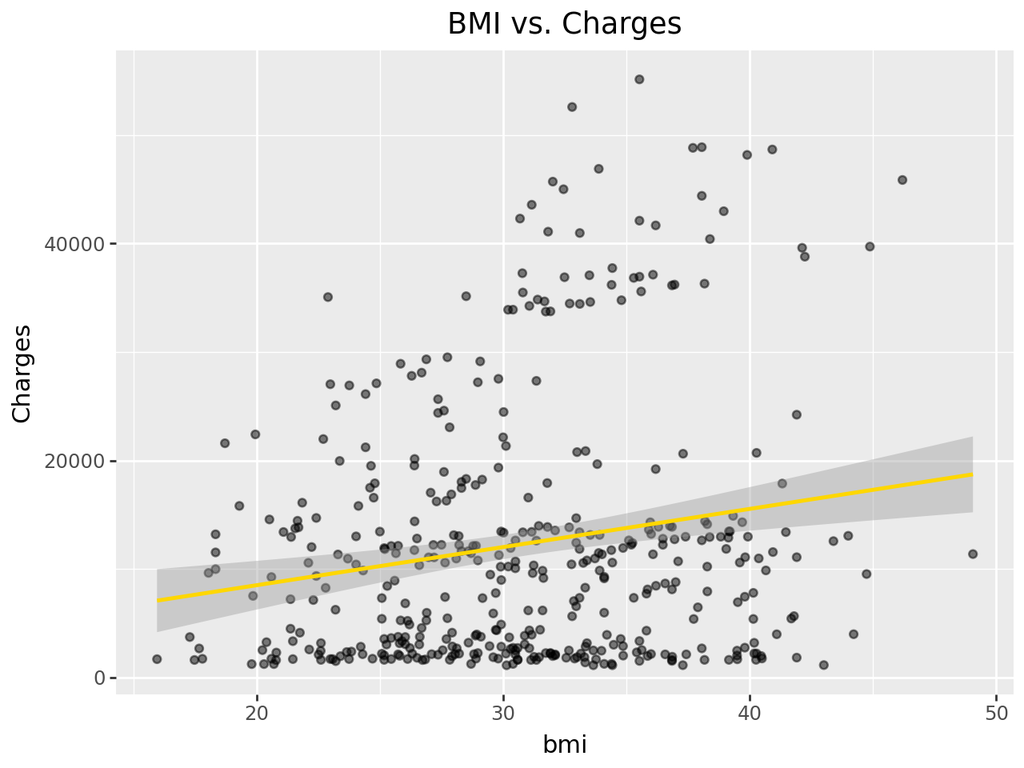

```python
plot2 = (ggplot(myData, aes(x="bmi", y="charges")) +
         geom_point(alpha=0.5) +
         geom_smooth(method="lm", color="gold") +
         labs(title="BMI vs. Charges", x="bmi", y="Charges"))
plot2
```

[figure not shown]

```python
plot3 = (ggplot(myData, aes(x="sex", y="charges", fill='region')) +
         geom_boxplot(alpha=0.5) +
         labs(title="Smoking vs. Charges", x="Children", y="Charges") +
         theme(figure_size=(10,6)))
plot3
```

**We will need to dummify sex to use in the regression.**

```python
myData = pd.get_dummies(myData, columns=["sex", "smoker"], drop_first=True)
map_dummy = {True:1, False: 0}
pd.set_option('future.no_silent_downcasting', True)
myData = myData.replace(map_dummy)
myData.head()
```

|  | age | bmi | region | charges | sex_male | smoker_yes |
| --- | --- | --- | --- | --- | --- | --- |
| 0 | 19 | 27.900 | southwest | 16884.92400 | 0 | 1 |
| 1 | 33 | 22.705 | northwest | 21984.47061 | 1 | 0 |
| 2 | 32 | 28.880 | northwest | 3866.85520 | 1 | 0 |
| 3 | 31 | 25.740 | southeast | 3756.62160 | 0 | 0 |
| 4 | 60 | 25.840 | northwest | 28923.13692 | 0 | 0 |

**PART 2**

```python
#Part 1

X1 = myData[['age']]
y = myData["charges"]
```

```python
X_train, X_test, y_train, y_test = train_test_split(X1,y, test_size =.2, random_state=321)
model1 = LinearRegression().fit(X_train,y_train)
y_pred_test1 = model1.predict(X_test)
```

```python
intercept1 = model1.intercept_
coefs1 = model1.coef_
mse_test1 = mean_squared_error(y_test, y_pred_test1)
r_squared_test1 = r2_score(y_test, y_pred_test1)

print("Model 1 - age only PV")
print(f"intercept: {intercept1:.4f}")
print(f"age coefficient: {coefs1[0]:.4f}")
print(f"mse_test: {mse_test1:.4f}")
print(f"r_squared_test: {r_squared_test1:.4f}")
```

```
Model 1 - age only PV
intercept: 3782.5329
age coefficient: 217.5566
mse_test: 145557939.9188
r_squared_test: 0.0952
```

```python
#Part 2
X2 = myData[['age', 'sex_male']]
```

```python
X_train, X_test, y_train, y_test = train_test_split(X2, y, test_size=0.2, random_state=321)
model2 = LinearRegression().fit(X_train,y_train)
y_pred_test2 = model2.predict(X_test)
```

```python
intercept2 = model2.intercept_
coefs2 = model2.coef_
mse_test2 = mean_squared_error(y_test, y_pred_test2)
r_squared_test2 = r2_score(y_test, y_pred_test2)

print("Model 2 - Age and Sex")
print(f"intercept: {intercept2:.4f}")
print(f"age coefficient: {coefs2[0]:.4f}")
print(f"male coefficient: {coefs2[1]:.4f}")
print(f"mse_test: {mse_test2:.4f}")
print(f"r_squared_test: {r_squared_test2:.4f}")
```

```
Model 2 - Age and Sex
intercept: 3803.8158
age coefficient: 217.6554
male coefficient: -55.1103
mse_test: 145654488.3792
r_squared_test: 0.0946
```

**Interpretation (Age): All else constant, as age increases by 1 year, we see an increase in medical costs (charges), on average, of $217.66.**

**Interpretation (sex): All else constant, we see medical costs (charges), on average, are $55.11 lower for males compared to females.**

```python
#Part 3
X3 = myData[['age', 'smoker_yes']]
```

```python
X_train, X_test, y_train, y_test = train_test_split(X3, y, test_size=0.2, random_state=321)
model3 = LinearRegression().fit(X_train,y_train)
y_pred_test3 = model3.predict(X_test)
```

```python
intercept3 = model3.intercept_
coefs3 = model3.coef_
mse_test3 = mean_squared_error(y_test, y_pred_test3)
r_squared_test3 = r2_score(y_test, y_pred_test3)

print("Model 3 - Age and Smoker")
print(f"intercept: {intercept3:.4f}")
print(f"age coefficient: {coefs3[0]:.4f}")
print(f"smoker_coefficient: {coefs3[1]:.4f}")
print(f"mse_test: {mse_test3:.4f}")
print(f"r_squared_test: {r_squared_test3:.4f}")
```

```
Model 3 - Age and Smoker
intercept: -2269.9424
age coefficient: 250.6943
smoker_coefficient: 23633.0009
mse_test: 41531273.1693
r_squared_test: 0.7418
```

**Interpretation (Age): All else constant, as age increases by 1 year, we see an increase in medical costs (charges), on average, of $250.69.**

**Interpretation (smoker): All else constant, we see medical costs (charges), on average, are $23,633 higher for smokers compared to nonsmokers.**

```python
table = pd.DataFrame(data = {"model 1": [mse_test1, r_squared_test1] , "model 2": [mse_test2, r_squared_test2], "model 3": [mse_test3, r_squared_test3]}, index=['MSE',"R^2"])
table.style.format('{:,.4f}')
```

|  | model 1 | model 2 | model 3 |
| --- | --- | --- | --- |
| MSE | 145,557,939.9188 | 145,654,488.3792 | 41,531,273.1693 |
| R^2 | 0.0952 | 0.0946 | 0.7418 |

**Between model 2 and 3, we find that model 3 better fits the data as it has a lower RMSE value and higher R-squared, which means that the PVs selected do a better job explaining the DV.**

**Part 3**

```python
#part1
X4 = myData[["age","bmi"]]
```

```python
X_train, X_test, y_train, y_test = train_test_split(X4, y, test_size=0.2, random_state=321)
model4 = LinearRegression().fit(X_train,y_train)
y_pred_test4 = model4.predict(X_test)

mse_test4 = mean_squared_error(y_test, y_pred_test4)
r_squared_test4 = r2_score(y_test, y_pred_test4)

print("Model 4 - Age and Bmi")
print(f"mse_test: {mse_test4:.4f}")
print(f"r_squared_test: {r_squared_test4:.4f}")
```

```
Model 4 - Age and Bmi
mse_test: 141459330.3572
r_squared_test: 0.1206
```

```python
#part2
myData['age2'] = myData['age']**2
X5 = myData[["age","age2"]]
```

```python
X_train, X_test, y_train, y_test = train_test_split(X5, y, test_size=0.2, random_state=321)
model5 = LinearRegression().fit(X_train,y_train)
y_pred_test5 = model5.predict(X_test)

mse_test5 = mean_squared_error(y_test, y_pred_test5)
r_squared_test5 = r2_score(y_test, y_pred_test5)

print("Model 5 - Age and Age^2")
print(f"mse_test: {mse_test5: .4f}")
print(f"r_squared_test: {r_squared_test5:.4f}")
```

```
Model 5 - Age and Age^2
mse_test:  145487834.9730
r_squared_test: 0.0956
```

```python
table2 = pd.DataFrame(data = {"model 1": [mse_test1, r_squared_test1] , "model 4": [mse_test4, r_squared_test4], "model 5": [mse_test5, r_squared_test5]}, index=['MSE',"R^2"])
table2.style.format('{:,.4f}')
```

|  | model 1 | model 4 | model 5 |
| --- | --- | --- | --- |
| MSE | 145,557,939.9188 | 141,459,330.3572 | 145,487,834.9730 |
| R^2 | 0.0952 | 0.1206 | 0.0956 |

Part1: Compared to Model1, Model4 has a slightly lower MSE and higher R^2, which may indicate that including BMI explains more of the DV compared to just having age.

Part2: There’s not much of a difference betweeen model 1 and model 5. The quadratic term doesn’t seem to explain a lot of the data as it doesn’t vary too much from the model with just age.

```python
#part 3
myData['age3'] = myData['age'] ** 3
myData['age4'] = myData['age'] ** 4
X6 = myData[["age","age2", "age3", "age4"]]
```

```python
X_train, X_test, y_train, y_test = train_test_split(X6, y, test_size=0.2, random_state=321)
model6 = LinearRegression().fit(X_train,y_train)
y_pred_test6 = model6.predict(X_test)

mse_test6 = mean_squared_error(y_test, y_pred_test6)
r_squared_test6 = r2_score(y_test, y_pred_test6)

print("Model 6 - Age Poly 4")
print(f"mse_test: {mse_test6: .4f}")
print(f"r_squared_test: {r_squared_test6:.4f}")
```

```
Model 6 - Age Poly 4
mse_test:  150661511.9743
r_squared_test: 0.0634
```

```python
intercept6 = model6.intercept_
coefs6 = model6.coef_
mse_test6 = mean_squared_error(y_test, y_pred_test6)
r_squared_test6 = r2_score(y_test, y_pred_test6)

print("Model 6 - Age Poly 4")
print(f"intercept: {intercept6:.4f}")
print(f"mse_test: {mse_test6: .4f}")
print(f"r_squared_test: {r_squared_test6:.4f}")
```

```
Model 6 - Age Poly 4
intercept: 114764.4435
mse_test:  150661511.9743
r_squared_test: 0.0634
```

```python
#part 4

#define x as the variable to make a degree
#poly = PolynomialFeatures(degree=4, include_bias=False)
#X_poly = poly.fit_transform(X) - use this in the y-test

myData['age5'] = myData['age'] ** 5
myData['age6'] = myData['age'] ** 6
myData['age7'] = myData['age'] ** 7
myData['age8'] = myData['age'] ** 8
myData['age9'] = myData['age'] ** 9
myData['age10'] = myData['age'] ** 10
myData['age11'] = myData['age'] ** 11
myData['age12'] = myData['age'] ** 12
X7 = myData[["age","age2", "age3", "age4", "age5","age6", "age7", "age8", "age9","age10", "age11", "age12"]]
```

```python
X_train, X_test, y_train, y_test = train_test_split(X7, y, test_size=0.2, random_state=321)
model7 = LinearRegression().fit(X_train,y_train)
y_pred_test7 = model7.predict(X_test)

intercept7 = model7.intercept_
coefs7 = model7.coef_
mse_test7 = mean_squared_error(y_test, y_pred_test7)
r_squared_test7 = r2_score(y_test, y_pred_test7)

print("Model 7 - Age Poly 12")
print(f"mse_test: {mse_test7: .4f}")
print(f"r_squared_test: {r_squared_test7:.4f}")
```

```
Model 7 - Age Poly 12
mse_test:  157456280.5177
r_squared_test: 0.0212
```

```python
#Part 5
table3 = pd.DataFrame(data = {"model1": [mse_test1, r_squared_test1] , "model6": [mse_test6, r_squared_test6], "model7": [mse_test7, r_squared_test7]})
table3.style.format('{:,.4f}')
```

|  | model1 | model6 | model7 |
| --- | --- | --- | --- |
| 0 | 145,557,939.9188 | 150,661,511.9743 | 157,456,280.5177 |
| 1 | 0.0952 | 0.0634 | 0.0212 |

```python
table4 = pd.DataFrame(data = {"model1": [mse_test1, r_squared_test1] , "model2": [mse_test2, r_squared_test2], "model3": [mse_test3, r_squared_test3], "model4":[mse_test4, r_squared_test4], "model5": [mse_test5, r_squared_test5], "model6": [mse_test6, r_squared_test6], "model7": [mse_test7, r_squared_test7]})
table4.style.format('{:,.4f}')
```

|  | model1 | model2 | model3 | model4 | model5 | model6 | model7 |
| --- | --- | --- | --- | --- | --- | --- | --- |
| 0 | 145,557,939.9188 | 145,654,488.3792 | 41,531,273.1693 | 141,459,330.3572 | 145,487,834.9730 | 150,661,511.9743 | 157,456,280.5177 |
| 1 | 0.0952 | 0.0946 | 0.7418 | 0.1206 | 0.0956 | 0.0634 | 0.0212 |

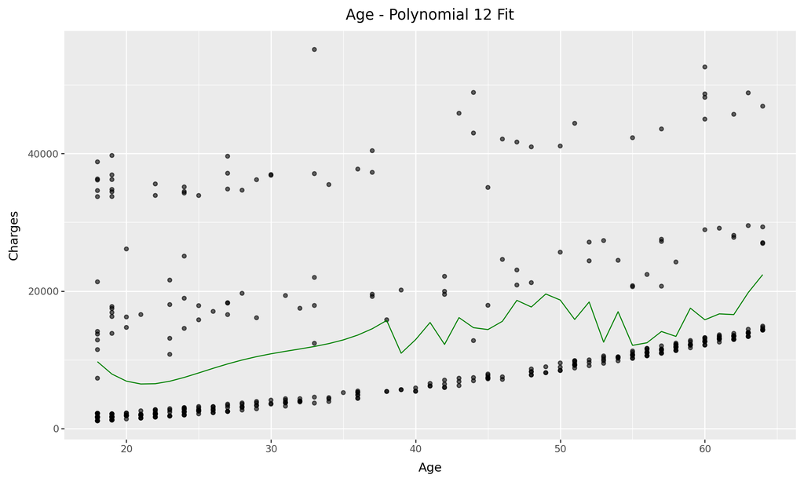

```python
y_hat_all = model7.predict(X7)
plot_data_poly12 = (
    pd.DataFrame({'age': X7['age'], 'charges': y_hat_all})
      .groupby('age', as_index=False)['charges'].mean()
      .sort_values('age')
)

poly12_plot = (
    ggplot(myData, aes(x='age', y='charges')) +
    geom_point(alpha=0.6) +
    geom_line(plot_data_poly12, aes(x='age', y='charges', group=1), color='green') +
    labs(title="Age - Polynomial 12 Fit", x="Age", y="Charges") +
    theme(figure_size=(10,6))
)
poly12_plot
```

**Could not get smooth given as this is likely for the graph having so many PVs that it is overfitting and attempting to follow the pattern of the original scatterplot**

**Part4**

```python
url2 = "https://www.dropbox.com/s/sky86agc4s8c6qe/insurance_costs_2.csv?dl=1"
myData2 = pd.read_csv(url2)
myData2.head()
```

|  | age | sex | bmi | smoker | region | charges |
| --- | --- | --- | --- | --- | --- | --- |
| 0 | 23 | male | 34.400 | no | southwest | 1826.84300 |
| 1 | 56 | male | 40.300 | no | southwest | 10602.38500 |
| 2 | 18 | male | 34.100 | no | southeast | 1137.01100 |
| 3 | 63 | female | 23.085 | no | northeast | 14451.83515 |
| 4 | 63 | male | 28.310 | no | northwest | 13770.09790 |

```python
myData2 = pd.get_dummies(myData2, columns=["sex", "smoker"], drop_first=True)
map_dummy = {True:1, False: 0}
pd.set_option('future.no_silent_downcasting', True)
myData2 = myData2.replace(map_dummy)
myData2.head()
```

|  | age | bmi | region | charges | sex_male | smoker_yes |
| --- | --- | --- | --- | --- | --- | --- |
| 0 | 23 | 34.400 | southwest | 1826.84300 | 1 | 0 |
| 1 | 56 | 40.300 | southwest | 10602.38500 | 1 | 0 |
| 2 | 18 | 34.100 | southeast | 1137.01100 | 1 | 0 |
| 3 | 63 | 23.085 | northeast | 14451.83515 | 0 | 0 |
| 4 | 63 | 28.310 | northwest | 13770.09790 | 1 | 0 |

```python
myData2["age_smoker"] = myData2["age"] * myData2["smoker_yes"]
myData2["bmi_smoker"] = myData2["bmi"] * myData2["smoker_yes"]
```

```python
Xd1 = myData2[['age']]
Xd2 = myData2[['age', 'bmi']]
Xd3 = myData2[['age','bmi','smoker_yes']]
Xd4 = myData2[['age','bmi','age_smoker','bmi_smoker']]
Xd5 = myData2[['age','bmi','smoker_yes','age_smoker','bmi_smoker']]
y2 = myData2["charges"]
```

```python
X_train, X_test, y_train, y_test = train_test_split(Xd1, y2, test_size=0.2, random_state=321)
mod1 = LinearRegression().fit(X_train,y_train)
y_pt1 = mod1.predict(X_test)

mse_t1 = mean_squared_error(y_test, y_pt1)

print("Model 1 - Data 2 - Age only PV")
print(f"mse_test: {mse_t1: .4f}")
```

```
Model 1 - Data 2 - Age only PV
mse_test:  106781877.9298
```

```python
X_train, X_test, y_train, y_test = train_test_split(Xd2, y2, test_size=0.2, random_state=321)
mod2 = LinearRegression().fit(X_train,y_train)
y_pt2 = mod2.predict(X_test)

mse_t2 = mean_squared_error(y_test, y_pt2)

print("Model 2 - Data 2 - Age and BMI")
print(f"mse_test: {mse_t2: .4f}")
```

```
Model 2 - Data 2 - Age and BMI
mse_test:  103268841.3714
```

```python
X_train, X_test, y_train, y_test = train_test_split(Xd3, y2, test_size=0.2, random_state=321)
mod3 = LinearRegression().fit(X_train,y_train)
y_pt3 = mod3.predict(X_test)

mse_t3 = mean_squared_error(y_test, y_pt3)

print("Model 3 - Data 2 - Age, BMI, and Smoker (no interaction)")
print(f"mse_test: {mse_t3: .4f}")
```

```
Model 3 - Data 2 - Age, BMI, and Smoker (no interaction)
mse_test:  32415360.3825
```

```python
X_train, X_test, y_train, y_test = train_test_split(Xd4, y2, test_size=0.2, random_state=321)
mod4 = LinearRegression().fit(X_train,y_train)
y_pt4 = mod4.predict(X_test)

mse_t4 = mean_squared_error(y_test, y_pt4)

print("Model 4 - Data 2 - Age, BMI, and interaction (age + bmi):smoker")
print(f"mse_test: {mse_t4: .4f}")
```

```
Model 4 - Data 2 - Age, BMI, and interaction (age + bmi):smoker
mse_test:  24682471.0551
```

```python
X_train, X_test, y_train, y_test = train_test_split(Xd5, y2, test_size=0.2, random_state=321)
mod5 = LinearRegression().fit(X_train,y_train)
y_pt5 = mod5.predict(X_test)

mse_t5 = mean_squared_error(y_test, y_pt5)

print("Model 5 - Data 2 - Age, BMI, Smoker, and interaction (age + bmi)*smoker")
print(f"mse_test: {mse_t5: .4f}")
```

```
Model 5 - Data 2 - Age, BMI, Smoker, and interaction (age + bmi)*smoker
mse_test:  24449651.0481
```

```python
table_data2 = pd.DataFrame(data = {"model1": [mse_t1] , "model2": [mse_t2], "model3": [mse_t3], "model4":[mse_t4], "model5": [mse_t5]}, index=['MSE'])
table_data2.style.format('{:,.4f}')
```

|  | model1 | model2 | model3 | model4 | model5 |
| --- | --- | --- | --- | --- | --- |
| MSE | 106,781,877.9298 | 103,268,841.3714 | 32,415,360.3825 | 24,682,471.0551 | 24,449,651.0481 |

**Out of all the models, it seems that model 5 with the 3 PVs and both interaction term has the lowest MSE. As a result, this suggests that this would be the best model to utilize.**

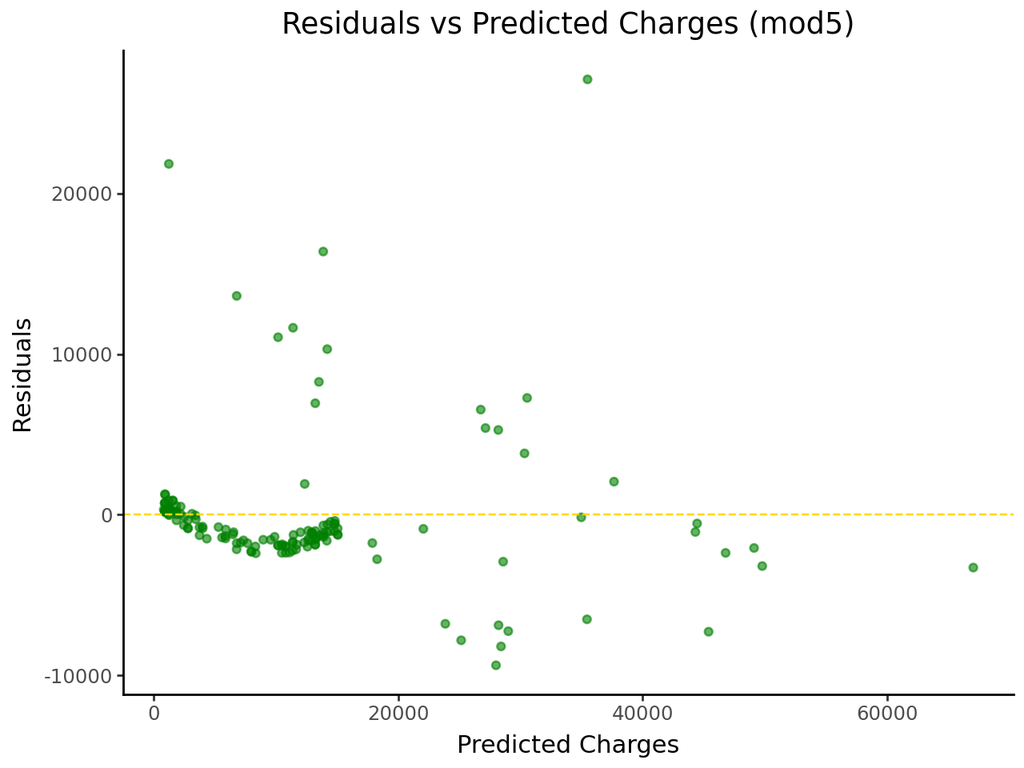

```python
Xd5_new = myData2[['age','bmi','smoker_yes','age_smoker','bmi_smoker']]
y_pt5_new = mod5.predict(Xd5_new)
residuals_mod5 = myData2['charges'] - y_pt5_new

resid_df = pd.DataFrame({'predicted': y_pt5_new, 'residuals': residuals_mod5})
(
    ggplot(resid_df, aes(x='predicted', y='residuals', color='blue'))
    + geom_point(alpha=0.6, color='green')
    + geom_hline(yintercept=0, linetype='dashed', color="gold")
    + labs(title='Residuals vs Predicted Charges (mod5)',
           x='Predicted Charges',
           y='Residuals')
    + theme_classic()
)
```

**Part 5 - Full Exploration**

- Age, bmi, sex, and smoker
- Age, Age^2, Age^3, bmi*smoker, and sex
- Age*smoker, bmi, bmi^2, bmi^3, sex

```python
myData2['bmi2'] = myData2['bmi'] ** 2
myData2['bmi3'] = myData2['bmi'] ** 3
myData2['age2'] = myData2['age'] ** 2
myData2['age3'] = myData2['age'] ** 3
```

```python
Xe1 = myData2[['age','bmi','sex_male','smoker_yes']]
Xe2 = myData2[['age','age2','age3','bmi_smoker','sex_male']]
Xe3 = myData2[['age_smoker', 'bmi', 'bmi2', 'bmi3', 'sex_male']]
```

```python
#first model of choice
X_train, X_test, y_train, y_test = train_test_split(Xe1, y2, test_size=0.2, random_state=321)
mode1 = LinearRegression().fit(X_train,y_train)
y_p1 = mode1.predict(X_test)

mse1 = mean_squared_error(y_test, y_p1)
r_squared1 = r2_score(y_test, y_p1)

print("Model 1 - Age, Bmi, Smoker, and Sex")
print(f"mse_test: {mse1:.4f}")
print(f"r_squared_test: {r_squared1:.4f}")
```

[output not shown]

```python
#second model of choice
X_train, X_test, y_train, y_test = train_test_split(Xe2, y2, test_size=0.2, random_state=321)
mode2 = LinearRegression().fit(X_train,y_train)
y_p2 = mode2.predict(X_test)

mse2 = mean_squared_error(y_test, y_p2)
r_squared2 = r2_score(y_test, y_p2)

print("Model 2 - Age Poly 3, Bmi*Smoker, and Sex")
print(f"mse_test: {mse2:.4f}")
print(f"r_squared_test: {r_squared2:.4f}")
```

[output not shown]

```python
#third model of choice
X_train, X_test, y_train, y_test = train_test_split(Xe3, y2, test_size=0.2, random_state=321)
mode3 = LinearRegression().fit(X_train,y_train)
y_p3 = mode3.predict(X_test)

mse3 = mean_squared_error(y_test, y_p3)
r_squared3 = r2_score(y_test, y_p3)

print("Model 3 - Age *Smoker, Bmi Poly 3, and Sex")
print(f"mse_test: {mse3:.4f}")
print(f"r_squared_test: {r_squared3:.4f}")
```

[output not shown]

```python
table5 = pd.DataFrame(data = {"model1": [mse1, r_squared1] , "model2": [mse_test6, r_squared_test6], "model7": [mse_test7, r_squared_test7]})
table5.style.format('{:,.4f}')
```

|  | model1 | model2 | model7 |
| --- | --- | --- | --- |
| 0 | 32,442,498.8112 | 150,661,511.9743 | 157,456,280.5177 |
| 1 | 0.6891 | 0.0634 | 0.0212 |

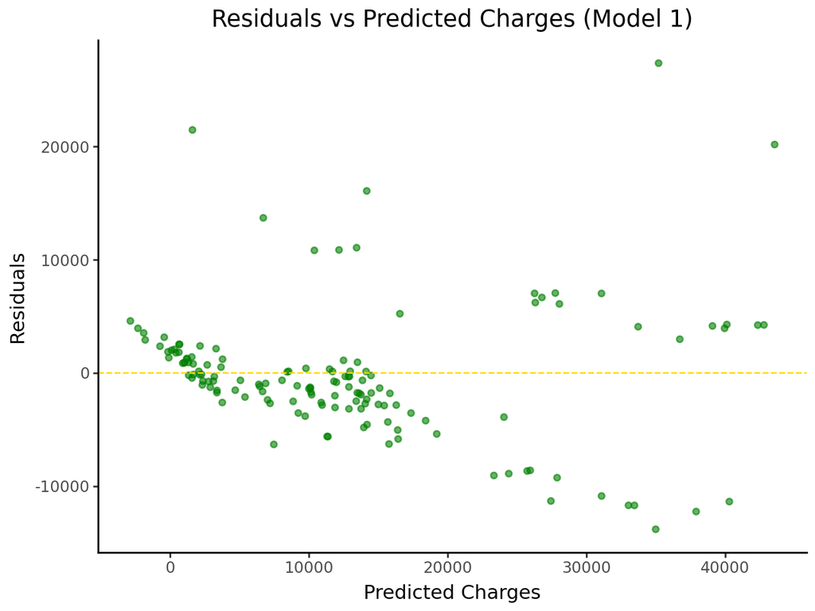

```python
Xe1_new = myData2[['age','bmi','sex_male','smoker_yes']]
y_p1_new = mode1.predict(Xe1_new)
residuals_mode1 = myData2['charges'] - y_p1_new

resid_df2 = pd.DataFrame({'predicted': y_p1_new, 'residuals': residuals_mode1})
(    ggplot(resid_df2, aes(x='predicted', y='residuals', color='blue'))
    + geom_point(alpha=0.6, color='Green')
    + geom_hline(yintercept=0, linetype='dashed', color="gold")
    + labs(title='Residuals vs Predicted Charges (Model 1)',
           x='Predicted Charges',
           y='Residuals')
    + theme_classic()
)
```